# Acropora DEG Analysis

LM Gorman, AS Huffmyer

2025

# Setup

Set up workspace, set options, and load required packages.

```r
knitr::opts_chunk$set(echo = TRUE, warning = FALSE, message = FALSE)
```

Load libraries.

```r
options(stringsAsFactors = FALSE)
#if ("tidyverse" %in% rownames(installed.packages()) == 'FALSE') install.packages('tidyverse')
#if ("genefilter" %in% rownames(installed.packages()) == 'FALSE') install.packages('genefilter')
#if ("RColorBrewer" %in% rownames(installed.packages()) == 'FALSE') install.packages('RColorBrewer')
#if ("WGCNA" %in% rownames(installed.packages()) == 'FALSE') install.packages('WGCNA')
#if ("flashClust" %in% rownames(installed.packages()) == 'FALSE') install.packages('flashClust')
#if ("gridExtra" %in% rownames(installed.packages()) == 'FALSE') install.packages('gridExtra')
#if ("ComplexHeatmap" %in% rownames(installed.packages()) == 'FALSE') BiocManager::install("ComplexHeatmap")
#if ("DESeq2" %in% rownames(installed.packages()) == 'FALSE') BiocManager::install("DESeq2")
#if ("goseq" %in% rownames(installed.packages()) == 'FALSE') BiocManager::install("goseq")
#if ("dplyr" %in% rownames(installed.packages()) == 'FALSE') install.packages('dplyr')
#if ("clusterProfiler" %in% rownames(installed.packages()) == 'FALSE') BiocManager::install("clusterProfiler")
#if ("pheatmap" %in% rownames(installed.packages()) == 'FALSE') install.packages('pheatmap')
#if ("magrittr" %in% rownames(installed.packages()) == 'FALSE') install.packages('magrittr')
#if ("rtracklayer" %in% rownames(installed.packages()) == 'FALSE') BiocManager::install("rtracklayer")
#if ("GenomicRanges" %in% rownames(installed.packages()) == 'FALSE') BiocManager::install("GenomicRanges")
#if ("plyranges" %in% rownames(installed.packages()) == 'FALSE') BiocManager::install("plyranges")
#if ("GSEABase" %in% rownames(installed.packages()) == 'FALSE') BiocManager::install("GSEABase")
#if ("GOSim" %in% rownames(installed.packages()) == 'FALSE') BiocManager::install("GOSim")
#if ("stats" %in% rownames(installed.packages()) == 'FALSE') install.packages("stats")
#if ("ggdendro" %in% rownames(installed.packages()) == 'FALSE') BiocManager::install("ggdendro")
#if ("GO.db" %in% rownames(installed.packages()) == 'FALSE') BiocManager::install("GO.db")
#if ("rrvgo" %in% rownames(installed.packages()) == 'FALSE') BiocManager::install("rrvgo")
#if ("viridis" %in% rownames(installed.packages()) == 'FALSE') install.packages("viridis")
#if ("topGO" %in% rownames(installed.packages()) == 'FALSE') BiocManager::install("topGO")
#if ("biomaRt" %in% rownames(installed.packages()) == 'FALSE') BiocManager::install("biomaRt")
#if ("Rgraphviz" %in% rownames(installed.packages()) == 'FALSE') BiocManager::install("Rgraphviz")
#if ("EnhancedVolcano" %in% rownames(installed.packages()) == 'FALSE') BiocManager::install("EnhancedVolcano")
#if ("vegan" %in% rownames(installed.packages()) == 'FALSE') install.packages("vegan")
#if ("factoextra" %in% rownames(installed.packages()) == 'FALSE') install.packages("factoextra")
#if ("htmlTable" %in% rownames(installed.packages()) == 'FALSE') install.packages("htmlTable")


library("vegan")
library("factoextra")
library("viridis")
library("DESeq2")
library("tidyverse")
library("genefilter")
library("RColorBrewer")
#library("WGCNA")
library("flashClust")
library("gridExtra")
library("ComplexHeatmap")
library("goseq")
library("dplyr")
library("clusterProfiler")
library("pheatmap")
library("magrittr")
library("rtracklayer")
library("GenomicRanges")
library("plyranges")
library("GSEABase")
library("GOSim")
library("stats")
library("ggdendro")
library("GO.db")
library("rrvgo")
library("cowplot")
library("topGO")
library("biomaRt")
library("Rgraphviz")
library("EnhancedVolcano")
```

# Sample mapping

This table shows the total number of mapped reads of each sample of our samples to the *Acropora hyacinthus* genome from the Palumbi lab - available at: https://www.ncbi.nlm.nih.gov/datasets/genome/GCA_020536085.1/

```r
acropora_mapping <- tribble(
  ~treatment, ~sample_id, ~total_mapped_reads, ~total_primary_reads,  ~total_percent_mapped, ~primary_percent_mapped,
  "Acropora hyacinthus eaten", "497R", 3090986, 2760422, 2.22, 1.98,
  "Acropora hyacinthus eaten", "568R", 74142102, 66507248, 53.01, 50.29,
  "Acropora hyacinthus eaten", "410R", 80526182, 73098402, 46.17, 43.77,
  "Acropora hyacinthus eaten", "549R", 77332112, 69416060, 66.06, 63.60,
  "Acropora hyacinthus eaten", "414R", 87333162, 78162862, 38.67, 36.07,
  "Acropora hyacinthus eaten", "321RA", 101145264, 91192744, 75.26, 73.29,
  "Acropora hyacinthus eaten", "581R", 23750278, 21582796, 19.23, 17.78,
  "Acropora hyacinthus eaten", "370R", 34239394, 30624808, 24.31, 22.32,
  "Acropora hyacinthus control", "419R", 106151016, 94939130, 68.00, 65.52,
  "Acropora hyacinthus control", "331RA", 99763802, 88927416, 75.29, 73.09,
  "Acropora hyacinthus control", "336R", 110716976, 100464150, 61.04, 58.71,
  "Acropora hyacinthus control", "512R", 134343958, 121579012, 74.83, 72.91,
  "Acropora hyacinthus control", "380R", 99627838, 89986620, 74.16, 72.16,
  "Acropora hyacinthus control", "571R", 76962776, 69663792, 47.52, 45.04,
  "Acropora hyacinthus control", "586R", 87532254, 79263634, 68.31, 66.12,
  "Acropora hyacinthus control", "468R", 100108574, 90603050, 67.37, 65.14
  )

#Filter based on samples <5 million mapped and/or primary reads
acropora_mapping %>%
  filter(total_mapped_reads < 5000000)
```

```
## # A tibble: 1 × 6
##   treatment                 sample_id total_mapped_reads total_primary_reads
##   <chr>                     <chr>                  <dbl>               <dbl>
## 1 Acropora hyacinthus eaten 497R                 3090986             2760422
## # ℹ 2 more variables: total_percent_mapped <dbl>, primary_percent_mapped <dbl>
```

```r
acropora_mapping %>%
  filter(total_primary_reads < 5000000)
```

```
## # A tibble: 1 × 6
##   treatment                 sample_id total_mapped_reads total_primary_reads
##   <chr>                     <chr>                  <dbl>               <dbl>
## 1 Acropora hyacinthus eaten 497R                 3090986             2760422
## # ℹ 2 more variables: total_percent_mapped <dbl>, primary_percent_mapped <dbl>
```

Only sample 497R has less than 5 million total mapped and primary reads.

```r
#Make the table in descending order of total mapped reads
acropora_mapping %>%
  arrange(desc(total_mapped_reads)) %>%
  knitr::kable(caption = "Total mapped reads  from each sample to *Acropora hyacinthus* genome.", col.names = c("Treatment", "ID", "Total number of mapped reads", "Number of primary mapped reads", "Total % mapped", "Primary % mapped"))
```

Total mapped reads from each sample to *Acropora hyacinthus* genome.

| Treatment | ID | Total number of mapped reads | Number of primary mapped reads | Total % mapped | Primary % mapped |
| --- | --- | --- | --- | --- | --- |
| Acropora hyacinthus control | 512R | 134343958 | 121579012 | 74.83 | 72.91 |
| Acropora hyacinthus control | 336R | 110716976 | 100464150 | 61.04 | 58.71 |
| Acropora hyacinthus control | 419R | 106151016 | 94939130 | 68.00 | 65.52 |
| Acropora hyacinthus eaten | 321RA | 101145264 | 91192744 | 75.26 | 73.29 |
| Acropora hyacinthus control | 468R | 100108574 | 90603050 | 67.37 | 65.14 |
| Acropora hyacinthus control | 331RA | 99763802 | 88927416 | 75.29 | 73.09 |
| Acropora hyacinthus control | 380R | 99627838 | 89986620 | 74.16 | 72.16 |
| Acropora hyacinthus control | 586R | 87532254 | 79263634 | 68.31 | 66.12 |
| Acropora hyacinthus eaten | 414R | 87333162 | 78162862 | 38.67 | 36.07 |
| Acropora hyacinthus eaten | 410R | 80526182 | 73098402 | 46.17 | 43.77 |
| Acropora hyacinthus eaten | 549R | 77332112 | 69416060 | 66.06 | 63.60 |
| Acropora hyacinthus control | 571R | 76962776 | 69663792 | 47.52 | 45.04 |
| Acropora hyacinthus eaten | 568R | 74142102 | 66507248 | 53.01 | 50.29 |
| Acropora hyacinthus eaten | 370R | 34239394 | 30624808 | 24.31 | 22.32 |
| Acropora hyacinthus eaten | 581R | 23750278 | 21582796 | 19.23 | 17.78 |
| Acropora hyacinthus eaten | 497R | 3090986 | 2760422 | 2.22 | 1.98 |

```r
#Colour the cells <5 million
library("htmlTable")
## indices defining where the styles go
where <- rbind(c(1, 3), c(1, 4))
style <- c('background-color: red; color: white;',
           'background-color: red; color: white;'
           )

css.cell <- matrix('', nrow(acropora_mapping), ncol(acropora_mapping))
css.cell[where] <- style
htmlTable(acropora_mapping, css.cell = css.cell, dimnames = NULL, c("Treatment", "ID", "Total number of mapped reads", "Number of primary mapped reads", "Total % mapped", "Primary % mapped"))
```

|  | Treatment | ID | Total number of mapped reads | Number of primary mapped reads | Total % mapped | Primary % mapped |
| --- | --- | --- | --- | --- | --- | --- |
| 1 | Acropora hyacinthus eaten | 497R | 3090986 | 2760422 | 2.22 | 1.98 |
| 2 | Acropora hyacinthus eaten | 568R | 74142102 | 66507248 | 53.01 | 50.29 |
| 3 | Acropora hyacinthus eaten | 410R | 80526182 | 73098402 | 46.17 | 43.77 |
| 4 | Acropora hyacinthus eaten | 549R | 77332112 | 69416060 | 66.06 | 63.6 |
| 5 | Acropora hyacinthus eaten | 414R | 87333162 | 78162862 | 38.67 | 36.07 |
| 6 | Acropora hyacinthus eaten | 321RA | 101145264 | 91192744 | 75.26 | 73.29 |
| 7 | Acropora hyacinthus eaten | 581R | 23750278 | 21582796 | 19.23 | 17.78 |
| 8 | Acropora hyacinthus eaten | 370R | 34239394 | 30624808 | 24.31 | 22.32 |
| 9 | Acropora hyacinthus control | 419R | 106151016 | 94939130 | 68 | 65.52 |
| 10 | Acropora hyacinthus control | 331RA | 99763802 | 88927416 | 75.29 | 73.09 |
| 11 | Acropora hyacinthus control | 336R | 110716976 | 100464150 | 61.04 | 58.71 |
| 12 | Acropora hyacinthus control | 512R | 134343958 | 121579012 | 74.83 | 72.91 |
| 13 | Acropora hyacinthus control | 380R | 99627838 | 89986620 | 74.16 | 72.16 |
| 14 | Acropora hyacinthus control | 571R | 76962776 | 69663792 | 47.52 | 45.04 |
| 15 | Acropora hyacinthus control | 586R | 87532254 | 79263634 | 68.31 | 66.12 |
| 16 | Acropora hyacinthus control | 468R | 100108574 | 90603050 | 67.37 | 65.14 |

```r
acropora_mapping %>%
  filter(!(sample_id == "497R")) %>% #remove 497R
  group_by(treatment) %>%
  summarise(mean_total_mapped = mean(total_mapped_reads), mean_primary_mapped = mean(total_primary_reads))
```

```
## # A tibble: 2 × 3
##   treatment                   mean_total_mapped mean_primary_mapped
##   <chr>                                   <dbl>               <dbl>
## 1 Acropora hyacinthus control        101900899.           91928350.
## 2 Acropora hyacinthus eaten           68352642            61512131.
```

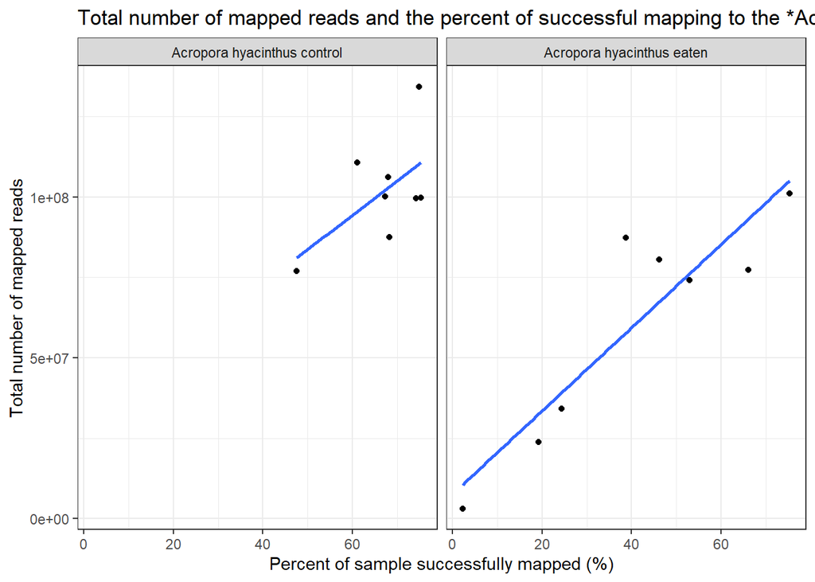

```r
acropora_mapping %>%
  ggplot(aes(total_percent_mapped, total_mapped_reads)) +
  geom_point() +
  facet_wrap(~treatment) +
  geom_smooth(method = 'lm', se = FALSE) +
  labs(title = "Total number of mapped reads and the percent of successful mapping to the *Acropora hyacinthus* genome", x = "Percent of sample successfully mapped (%)", y = "Total number of mapped reads") +
  theme_bw()
```

Similar to *Porites*, *Acropora hyacinthus* control samples have a much lower variability in the total number of mapped reads and those successfully mapped whereas the *Acropora hyacinthus* eaten treatment have a large range of both total reads and those successfully mapped. The general pattern shows that the more reads a sample has overall, the more that successfully mapped to the *Acropora hyacinthus* genome.

# Load and format data

Load *Acropora hyacinthus* metadata file.

```r
#Load metadata sheet with sample name and eaten vs control information
metadata <- read.csv("data/acr_rnaseq_metadata_gorman.csv", header = TRUE, sep = ",")%>%dplyr::select(sample, eatenvscontrol, code)
head(metadata)
```

```
##           sample eatenvscontrol         code
## 1 trim.321RA.gtf          eaten   Ahya_eaten
## 2 trim.331RA.gtf        control Ahya_control
## 3  trim.336R.gtf        control Ahya_control
## 4  trim.370R.gtf          eaten   Ahya_eaten
## 5  trim.380R.gtf        control Ahya_control
## 6  trim.410R.gtf          eaten   Ahya_eaten
```

Load gene count matrix.

```r
#Load A. hyacinthus gene count matrix generated from stringtie
gcount <- as.data.frame(read.csv("data/gene-count-matrix/acropora_gene_count_matrix.csv", row.names="gene_id"), colClasses = double)
head(gcount)
```

```
##                  trim.321RA.gtf trim.331RA.gtf trim.336R.gtf trim.370R.gtf
## Ahyacinthus26340              0             11             0             0
## Ahyacinthus26341             52              4             0             0
## Ahyacinthus26342            443             19             0             0
## Ahyacinthus26343              0              0             0            94
## Ahyacinthus26344             40             24             0            14
## Ahyacinthus26345              0              0             0             0
##                  trim.380R.gtf trim.410R.gtf trim.414R.gtf trim.419R.gtf
## Ahyacinthus26340            26             0             0           101
## Ahyacinthus26341             0             7            38             0
## Ahyacinthus26342             0            27           174             0
## Ahyacinthus26343             0             0             0           105
## Ahyacinthus26344             0            43            19           154
## Ahyacinthus26345             0             0             5             2
##                  trim.468R.gtf trim.497R.gtf trim.512R.gtf trim.549R.gtf
## Ahyacinthus26340            61            12           151             0
## Ahyacinthus26341             0             0            20             0
## Ahyacinthus26342             0             0            59             0
## Ahyacinthus26343            75            66           101             0
## Ahyacinthus26344            42             0            65           260
## Ahyacinthus26345             9             0             0             0
##                  trim.568R.gtf trim.571R.gtf trim.581R.gtf trim.586R.gtf
## Ahyacinthus26340             0             8             0             0
## Ahyacinthus26341             0             0             0             0
## Ahyacinthus26342             0            12             0             0
## Ahyacinthus26343             0            78            49            67
## Ahyacinthus26344             0             0             0           120
## Ahyacinthus26345             0             0             0             0
```

Remove genes with 0 counts in all samples.

```r
dim(gcount)
```

```
## [1] 27110    16
```

```r
gcount<-gcount %>%
  mutate(Total = rowSums(.[, 1:16]))%>%
  filter(!Total==0)%>%
  dplyr::select(!Total)

dim(gcount)
```

```
## [1] 25287    16
```

Started with 27110 genes, ended with 25287 genes.

# Filter the genes based on sample size using pOverA.

Currently have 16 samples total; 8 in eaten and 8 in control. Therefore 8/16 = `0.5` so we will use this filter parameter to make sure 50% of the genes have a gene count of >10.

```r
filt <- filterfun(pOverA(0.5,10))
#create filter for the counts data
gfilt <- genefilter(gcount, filt)
#identify genes to keep by count filter
gkeep <- gcount[gfilt,]
#identify gene lists
gn.keep <- rownames(gkeep)
gcount_filt <- as.data.frame(gcount[which(rownames(gcount) %in% gn.keep),])
#How many rows do we have before and after filtering?
nrow(gcount) #before
```

```
## [1] 25287
```

```r
nrow(gcount_filt) #after
```

```
## [1] 17634
```

We had 25287 genes before filtering. After filtering we have 17634 genes.

```r
#Function to extract 'R' followed by numbers from column names
extract_R_numbers <- function(col_names) {
  sub("R(\\d+).*", "\\1", col_names)
}

# Apply the function to all column names
new_col_names <- sapply(names(gcount_filt), extract_R_numbers)

# Output the modified dataframe
names(gcount_filt)
```

```
##  [1] "trim.321RA.gtf" "trim.331RA.gtf" "trim.336R.gtf"  "trim.370R.gtf"
##  [5] "trim.380R.gtf"  "trim.410R.gtf"  "trim.414R.gtf"  "trim.419R.gtf"
##  [9] "trim.468R.gtf"  "trim.497R.gtf"  "trim.512R.gtf"  "trim.549R.gtf"
## [13] "trim.568R.gtf"  "trim.571R.gtf"  "trim.581R.gtf"  "trim.586R.gtf"
```

```r
length(names(gcount_filt))
```

```
## [1] 16
```

# Editing the metadata files

```r
#Print the sample names in the metadata file
metadata$sample<-as.factor(metadata$sample)
metadata$eatenvscontrol<-as.factor(metadata$eatenvscontrol)
metadata$code<-as.factor(metadata$code)

# Set levels of factors.
metadata$eatenvscontrol<-factor(metadata$eatenvscontrol, levels=c("eaten", "control"))
metadata$code<-factor(metadata$code, levels=c("Ahya_eaten", "Ahya_control"))

#Make sure the metadata and the columns in the gene count matrix are all the same.
metadata$sample
```

```
##  [1] trim.321RA.gtf trim.331RA.gtf trim.336R.gtf  trim.370R.gtf  trim.380R.gtf
##  [6] trim.410R.gtf  trim.414R.gtf  trim.419R.gtf  trim.468R.gtf  trim.497R.gtf
## [11] trim.512R.gtf  trim.549R.gtf  trim.568R.gtf  trim.571R.gtf  trim.581R.gtf
## [16] trim.586R.gtf
## 16 Levels: trim.321RA.gtf trim.331RA.gtf trim.336R.gtf ... trim.586R.gtf
```

```r
colnames(gcount_filt)
```

```
##  [1] "trim.321RA.gtf" "trim.331RA.gtf" "trim.336R.gtf"  "trim.370R.gtf"
##  [5] "trim.380R.gtf"  "trim.410R.gtf"  "trim.414R.gtf"  "trim.419R.gtf"
##  [9] "trim.468R.gtf"  "trim.497R.gtf"  "trim.512R.gtf"  "trim.549R.gtf"
## [13] "trim.568R.gtf"  "trim.571R.gtf"  "trim.581R.gtf"  "trim.586R.gtf"
```

```r
list<-colnames(gcount_filt)
list<-as.factor(list)

#Make sure metadata$sample and column names are identical
metadata$sample <- tolower(trimws(metadata$sample))
colnames(gcount_filt) <- tolower(trimws(colnames(gcount_filt)))
identical(metadata$sample, colnames(gcount_filt))
```

```
## [1] TRUE
```

```r
# Re-order the data.frame
metadata$sample<-as.factor(metadata$sample)
metadata_ordered <- metadata[order(metadata$sample),]
metadata_ordered$sample
```

```
##  [1] trim.321ra.gtf trim.331ra.gtf trim.336r.gtf  trim.370r.gtf  trim.380r.gtf
##  [6] trim.410r.gtf  trim.414r.gtf  trim.419r.gtf  trim.468r.gtf  trim.497r.gtf
## [11] trim.512r.gtf  trim.549r.gtf  trim.568r.gtf  trim.571r.gtf  trim.581r.gtf
## [16] trim.586r.gtf
## 16 Levels: trim.321ra.gtf trim.331ra.gtf trim.336r.gtf ... trim.586r.gtf
```

```r
head(metadata_ordered)
```

```
##           sample eatenvscontrol         code
## 1 trim.321ra.gtf          eaten   Ahya_eaten
## 2 trim.331ra.gtf        control Ahya_control
## 3  trim.336r.gtf        control Ahya_control
## 4  trim.370r.gtf          eaten   Ahya_eaten
## 5  trim.380r.gtf        control Ahya_control
## 6  trim.410r.gtf          eaten   Ahya_eaten
```

```r
colnames(gcount_filt)
```

```
##  [1] "trim.321ra.gtf" "trim.331ra.gtf" "trim.336r.gtf"  "trim.370r.gtf"
##  [5] "trim.380r.gtf"  "trim.410r.gtf"  "trim.414r.gtf"  "trim.419r.gtf"
##  [9] "trim.468r.gtf"  "trim.497r.gtf"  "trim.512r.gtf"  "trim.549r.gtf"
## [13] "trim.568r.gtf"  "trim.571r.gtf"  "trim.581r.gtf"  "trim.586r.gtf"
```

```r
head(gcount_filt)
```

```
##                  trim.321ra.gtf trim.331ra.gtf trim.336r.gtf trim.370r.gtf
## Ahyacinthus26343              0              0             0            94
## Ahyacinthus26344             40             24             0            14
## Ahyacinthus07918            961            574           731            65
## Ahyacinthus07914            808            601           422           171
## Ahyacinthus07915           1376            879          1429            58
## Ahyacinthus07916            298            139           339             0
##                  trim.380r.gtf trim.410r.gtf trim.414r.gtf trim.419r.gtf
## Ahyacinthus26343             0             0             0           105
## Ahyacinthus26344             0            43            19           154
## Ahyacinthus07918           442           111           551          1319
## Ahyacinthus07914           398           151           216           907
## Ahyacinthus07915          1099           273           722          1382
## Ahyacinthus07916           285           101           336           176
##                  trim.468r.gtf trim.497r.gtf trim.512r.gtf trim.549r.gtf
## Ahyacinthus26343            75            66           101             0
## Ahyacinthus26344            42             0            65           260
## Ahyacinthus07918           404            23           175           394
## Ahyacinthus07914           437            37           635           167
## Ahyacinthus07915           659             0          1460           724
## Ahyacinthus07916           196             0           403           182
##                  trim.568r.gtf trim.571r.gtf trim.581r.gtf trim.586r.gtf
## Ahyacinthus26343             0            78            49            67
## Ahyacinthus26344             0             0             0           120
## Ahyacinthus07918           135           517             0           388
## Ahyacinthus07914            46           393             0           446
## Ahyacinthus07915           553           593           100           972
## Ahyacinthus07916             0           187             0           301
```

```r
gcount_filt <- gcount_filt[, order(colnames(gcount_filt))]
#Clean up metadata and gcount names by removing white spaces
metadata_ordered$sample <- tolower(trimws(metadata_ordered$sample))
colnames(gcount_filt) <- tolower(trimws(colnames(gcount_filt)))
#Check sample names are the same
identical(metadata_ordered$sample, colnames(gcount_filt))
```

```
## [1] TRUE
```

```r
#Make sure that the reference level for estimating effect size is control
metadata$eatenvscontrol <- relevel(metadata$eatenvscontrol, ref = "control")
```

# Estimate size factors

```r
#Construct DESEQDataSet Object called "gdds"
gdds <- DESeqDataSetFromMatrix(countData = gcount_filt,
                               colData = metadata,
                               design = ~eatenvscontrol)
#Estimate size factors
SF.gdds <- estimateSizeFactors(gdds)
print(sizeFactors(SF.gdds))
```

```
## trim.321ra.gtf trim.331ra.gtf  trim.336r.gtf  trim.370r.gtf  trim.380r.gtf
##      2.2871442      1.8919837      1.6063288      0.3334478      1.7893594
##  trim.410r.gtf  trim.414r.gtf  trim.419r.gtf  trim.468r.gtf  trim.497r.gtf
##      0.7715244      1.5798689      2.1550625      1.4701467      0.0557867
##  trim.512r.gtf  trim.549r.gtf  trim.568r.gtf  trim.571r.gtf  trim.581r.gtf
##      2.2710143      1.3615630      1.1315222      0.9437341      0.3060503
##  trim.586r.gtf
##      1.3888771
```

```r
all(sizeFactors(SF.gdds)) < 4
```

```
## [1] TRUE
```

All size factors are less than 4, so we can use VST transformation.

# Run vst to transform data

```r
gvst <- vst(gdds, blind=FALSE) #apply a variance stabilizing transforamtion to minimize effects of small counts and normalize wrt library size
head(assay(gvst), 3) #view transformed gene count data for the first three genes.
```

```
##                  trim.321ra.gtf trim.331ra.gtf trim.336r.gtf trim.370r.gtf
## Ahyacinthus26343       6.516791       6.516791      6.516791      8.801715
## Ahyacinthus26344       7.142375       7.050705      6.516791      7.475929
## Ahyacinthus07918       9.202318       8.872310      9.287235      8.469287
##                  trim.380r.gtf trim.410r.gtf trim.414r.gtf trim.419r.gtf
## Ahyacinthus26343      6.516791      6.516791      6.516791      7.547116
## Ahyacinthus26344      6.516791      7.615576      7.036808      7.753087
## Ahyacinthus07918      8.678380      8.223822      9.010221      9.615625
##                  trim.468r.gtf trim.497r.gtf trim.512r.gtf trim.549r.gtf
## Ahyacinthus26343      7.570079     10.409445      7.502909      6.516791
## Ahyacinthus26344      7.312498      6.516791      7.313218      8.451824
## Ahyacinthus07918      8.777530      9.182372      7.797751      8.826690
##                  trim.568r.gtf trim.571r.gtf trim.581r.gtf trim.586r.gtf
## Ahyacinthus26343      6.516791      7.840504      8.307306      7.542211
## Ahyacinthus26344      6.516791      6.516791      6.516791      7.868224
## Ahyacinthus07918      8.085187      9.490460      6.516791      8.793112
```

```r
dim(gvst)
```

```
## [1] 17634    16
```

# Plot a heatmap to sample distances

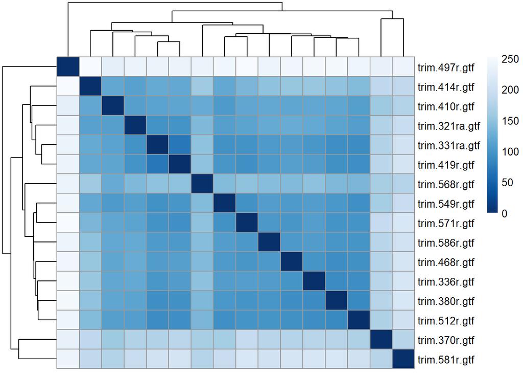

```r
gsampleDists <- dist(t(assay(gvst))) #calculate distance matix
gsampleDistMatrix <- as.matrix(gsampleDists) #distance matrix
rownames(gsampleDistMatrix) <- colnames(gvst) #assign row names
colnames(gsampleDistMatrix) <- NULL #assign col names
colors <- colorRampPalette( rev(brewer.pal(9, "Blues")) )(255) #assign colors
save_pheatmap_pdf <- function(x, filename, width=7, height=7) {
  stopifnot(!missing(x))
  stopifnot(!missing(filename))
  pdf(filename, width=width, height=height)
  grid::grid.newpage()
  grid::grid.draw(x$gtable)
  dev.off()
}

pht<-pheatmap(gsampleDistMatrix, #plot matrix
              clustering_distance_rows=gsampleDists, #cluster rows
              clustering_distance_cols=gsampleDists, #cluster columns
              col=colors) #set colors
```

```r
save_pheatmap_pdf(pht, "figures/acropora/acr_sample_distances.pdf")
```

```r
dev.off()
```

Heatmap shows a clear diagnol line emphasising that the metadata is correctly mapping to the right sample in the genecount matrix. No diagonal line would mean it is not mapping correctly to sample name.

# Conduct a PERMANOVA and PCA for all genes

```r
#Export data for PERMANOVA test.
test<-t(assay(gvst)) #export as matrix
test<-as.data.frame(test)
#add category columns
test$sample<-rownames(test)
test$eatenvscontrol<-metadata$eatenvscontrol[match(test$sample, metadata$sample)]
dim(test)
```

```
## [1]    16 17636
```

Two of these 17636 columns are metadata so real value is 1.7634^{4} genes **as expected**

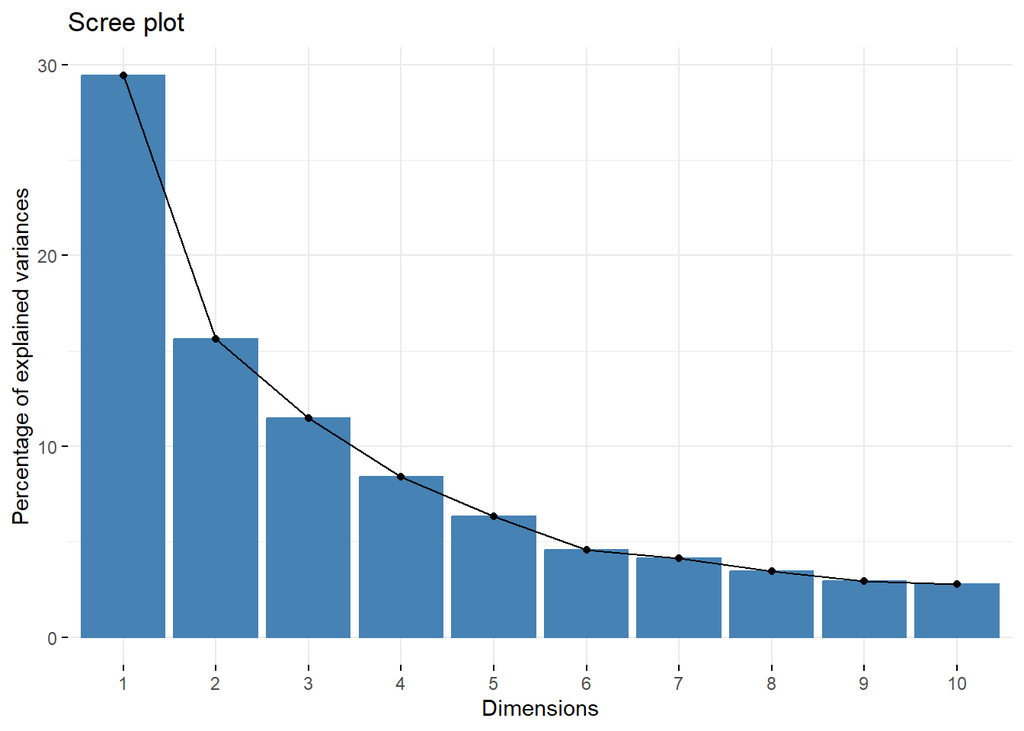

```r
scaled_test <-prcomp(test[c(1:17634)], scale=TRUE, center=TRUE)
fviz_eig(scaled_test)
```

```r
# scale data
vegan <- scale(test[c(1:17634)])

# PerMANOVA
permanova<-adonis2(vegan ~ eatenvscontrol, data = test, method='eu')
permanova
```

```
## Permutation test for adonis under reduced model
## Permutation: free
## Number of permutations: 999
##
## adonis2(formula = vegan ~ eatenvscontrol, data = test, method = "eu")
##          Df SumOfSqs      R2      F Pr(>F)
## Model     1    38615 0.14599 2.3932  0.001 ***
## Residual 14   225895 0.85401
## Total    15   264510 1.00000
## ---
## Signif. codes:  0 '***' 0.001 '**' 0.01 '*' 0.05 '.' 0.1 ' ' 1
```

# Plot a PCA of samples by eatenvscontrol phenotype for all genes.

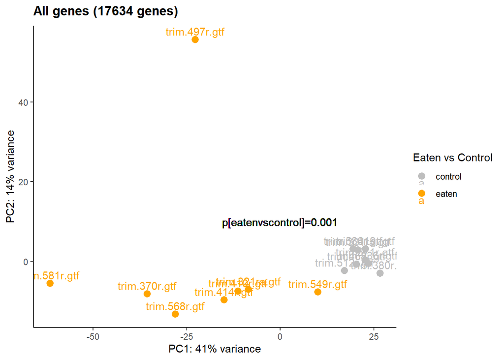

```r
gPCAdata <- plotPCA(gvst, intgroup = c("eatenvscontrol"), returnData=TRUE)
percentVar <- round(100*attr(gPCAdata, "percentVar"))

allgenesfilt_PCA <- ggplot(gPCAdata, aes(PC1, PC2, color=eatenvscontrol)) +
  geom_point(size=3) +
  ggtitle(expression(bold("All genes (17634 genes)")))+
  geom_text(aes(x = PC1, y = PC2, label = name), vjust = -0.5) +
  xlab(paste0("PC1: ",percentVar[1],"% variance")) +
  ylab(paste0("PC2: ",percentVar[2],"% variance")) +
  scale_color_manual(name="Eaten vs Control", values=c("control"="gray", "eaten"="orange"))+
  geom_text(x=0, y=10, label="p[eatenvscontrol]=0.001", color="black")+
  theme_classic() + #Set background color
  theme(panel.border = element_blank(), # Set border
        #panel.grid.major = element_blank(), #Set major gridlines
        #panel.grid.minor = element_blank(), #Set minor gridlines
        axis.line = element_line(colour = "black"), #Set axes color
        plot.background=element_blank()); allgenesfilt_PCA
```

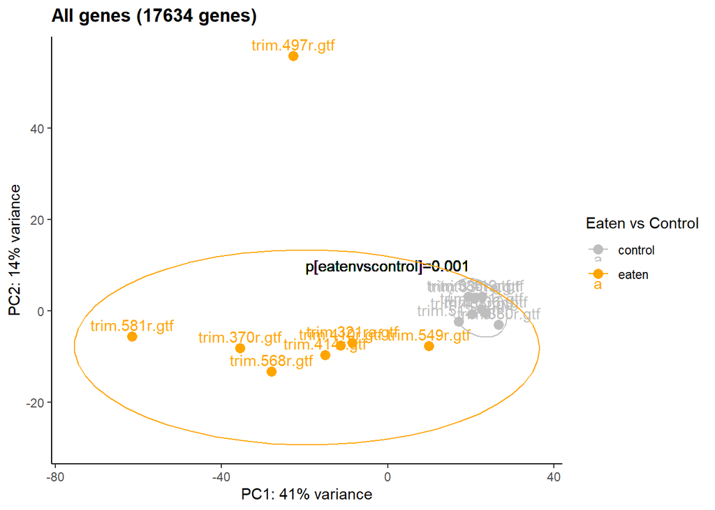

```r
ggsave("figures/acropora/pca_acr.pdf", allgenesfilt_PCA, width=8, height=4)
ggsave("figures/acropora/pca_acr.jpeg", allgenesfilt_PCA, width=8, height=4)

#Add a plot with elipses.
allgenes_ellipse<-allgenesfilt_PCA + stat_ellipse();allgenes_ellipse
```

```r
ggsave("figures/acropora/pca_acr_ellipse.pdf", allgenes_ellipse, width=9, height=5)
ggsave("figures/acropora/pca_acr_ellipse.jpeg", allgenes_ellipse, width=9, height=5)
```

# Removing sample 497R and re-running the analysis

```r
#Create new dataset without 497R
metadata_2 <- metadata[-10,]
metadata_2
```

```
##            sample eatenvscontrol         code
## 1  trim.321ra.gtf          eaten   Ahya_eaten
## 2  trim.331ra.gtf        control Ahya_control
## 3   trim.336r.gtf        control Ahya_control
## 4   trim.370r.gtf          eaten   Ahya_eaten
## 5   trim.380r.gtf        control Ahya_control
## 6   trim.410r.gtf          eaten   Ahya_eaten
## 7   trim.414r.gtf          eaten   Ahya_eaten
## 8   trim.419r.gtf        control Ahya_control
## 9   trim.468r.gtf        control Ahya_control
## 11  trim.512r.gtf        control Ahya_control
## 12  trim.549r.gtf          eaten   Ahya_eaten
## 13  trim.568r.gtf          eaten   Ahya_eaten
## 14  trim.571r.gtf        control Ahya_control
## 15  trim.581r.gtf          eaten   Ahya_eaten
## 16  trim.586r.gtf        control Ahya_control
```

Remove 497R from gene count matrix.

```r
#Remove 497R
gcount_2 <- gcount[,-10]
```

Re-run all previous analysis by adding “_2” to previous names of data objects Remove genes with 0 counts in all samples.

```r
dim(gcount_2)
```

```
## [1] 25287    15
```

```r
gcount_2<-gcount_2 %>%
  mutate(Total = rowSums(.[, 1:15]))%>%
  filter(!Total==0)%>%
  dplyr::select(!Total)

dim(gcount_2)
```

```
## [1] 25283    15
```

# Filter the genes based on sample size using pOverA.

```r
filt_2 <- filterfun(pOverA(0.44,10))
#create filter for the counts data
gfilt_2 <- genefilter(gcount_2, filt_2)
#identify genes to keep by count filter
gkeep_2 <- gcount_2[gfilt_2,]
#identify gene lists
gn.keep_2 <- rownames(gkeep_2)
gcount_filt_2 <- as.data.frame(gcount_2[which(rownames(gcount_2) %in% gn.keep_2),])
#How many rows do we have before and after filtering?
nrow(gcount_2) #before
```

```
## [1] 25283
```

```r
nrow(gcount_filt_2) #after
```

```
## [1] 18258
```

```r
write.csv(gcount_filt_2,"data/allgenes_acr.csv", row.names = FALSE)
```

We had 25283 genes before filtering. After filtering we have 18258 genes.

```r
#Function to extract 'R' followed by numbers from column names
extract_R_numbers_2 <- function(col_names) {
  sub("R(\\d+).*", "\\1", col_names)
}

# Apply the function to all column names
new_col_names_2 <- sapply(names(gcount_filt_2), extract_R_numbers_2)

# Output the modified dataframe
names(gcount_filt_2)
```

```
##  [1] "trim.321RA.gtf" "trim.331RA.gtf" "trim.336R.gtf"  "trim.370R.gtf"
##  [5] "trim.380R.gtf"  "trim.410R.gtf"  "trim.414R.gtf"  "trim.419R.gtf"
##  [9] "trim.468R.gtf"  "trim.512R.gtf"  "trim.549R.gtf"  "trim.568R.gtf"
## [13] "trim.571R.gtf"  "trim.581R.gtf"  "trim.586R.gtf"
```

```r
length(names(gcount_filt_2))
```

```
## [1] 15
```

# Editing the metadata files

```r
#Print the sample names in the metadata file
metadata_2$sample<-as.factor(metadata_2$sample)
metadata_2$eatenvscontrol<-as.factor(metadata_2$eatenvscontrol)
metadata_2$code<-as.factor(metadata_2$code)

# Set levels of factors.
metadata_2$eatenvscontrol<-factor(metadata_2$eatenvscontrol, levels=c("eaten", "control"))
metadata_2$code<-factor(metadata_2$code, levels=c("Ahya_eaten", "Ahya_control"))

#Make sure the metadata and the columns in the gene count matrix are all the same.
metadata_2$sample
```

```
##  [1] trim.321ra.gtf trim.331ra.gtf trim.336r.gtf  trim.370r.gtf  trim.380r.gtf
##  [6] trim.410r.gtf  trim.414r.gtf  trim.419r.gtf  trim.468r.gtf  trim.512r.gtf
## [11] trim.549r.gtf  trim.568r.gtf  trim.571r.gtf  trim.581r.gtf  trim.586r.gtf
## 16 Levels: trim.321ra.gtf trim.331ra.gtf trim.336r.gtf ... trim.586r.gtf
```

```r
colnames(gcount_filt_2)
```

```
##  [1] "trim.321RA.gtf" "trim.331RA.gtf" "trim.336R.gtf"  "trim.370R.gtf"
##  [5] "trim.380R.gtf"  "trim.410R.gtf"  "trim.414R.gtf"  "trim.419R.gtf"
##  [9] "trim.468R.gtf"  "trim.512R.gtf"  "trim.549R.gtf"  "trim.568R.gtf"
## [13] "trim.571R.gtf"  "trim.581R.gtf"  "trim.586R.gtf"
```

```r
list_2<-colnames(gcount_filt_2)
list_2<-as.factor(list_2)

#Make sure metadata_2$sample and column names are identical
metadata_2$sample <- tolower(trimws(metadata_2$sample))
colnames(gcount_filt_2) <- tolower(trimws(colnames(gcount_filt_2)))
identical(metadata_2$sample, colnames(gcount_filt_2))
```

```
## [1] TRUE
```

```r
# Re-order the data.frame
metadata_2$sample<-as.factor(metadata_2$sample)
metadata_ordered_2 <- metadata_2[order(metadata_2$sample),]
metadata_ordered_2$sample
```

```
##  [1] trim.321ra.gtf trim.331ra.gtf trim.336r.gtf  trim.370r.gtf  trim.380r.gtf
##  [6] trim.410r.gtf  trim.414r.gtf  trim.419r.gtf  trim.468r.gtf  trim.512r.gtf
## [11] trim.549r.gtf  trim.568r.gtf  trim.571r.gtf  trim.581r.gtf  trim.586r.gtf
## 15 Levels: trim.321ra.gtf trim.331ra.gtf trim.336r.gtf ... trim.586r.gtf
```

```r
head(metadata_ordered_2)
```

```
##           sample eatenvscontrol         code
## 1 trim.321ra.gtf          eaten   Ahya_eaten
## 2 trim.331ra.gtf        control Ahya_control
## 3  trim.336r.gtf        control Ahya_control
## 4  trim.370r.gtf          eaten   Ahya_eaten
## 5  trim.380r.gtf        control Ahya_control
## 6  trim.410r.gtf          eaten   Ahya_eaten
```

```r
colnames(gcount_filt_2)
```

```
##  [1] "trim.321ra.gtf" "trim.331ra.gtf" "trim.336r.gtf"  "trim.370r.gtf"
##  [5] "trim.380r.gtf"  "trim.410r.gtf"  "trim.414r.gtf"  "trim.419r.gtf"
##  [9] "trim.468r.gtf"  "trim.512r.gtf"  "trim.549r.gtf"  "trim.568r.gtf"
## [13] "trim.571r.gtf"  "trim.581r.gtf"  "trim.586r.gtf"
```

```r
head(gcount_filt_2)
```

```
##                  trim.321ra.gtf trim.331ra.gtf trim.336r.gtf trim.370r.gtf
## Ahyacinthus26343              0              0             0            94
## Ahyacinthus26344             40             24             0            14
## Ahyacinthus07918            961            574           731            65
## Ahyacinthus07914            808            601           422           171
## Ahyacinthus07915           1376            879          1429            58
## Ahyacinthus07916            298            139           339             0
##                  trim.380r.gtf trim.410r.gtf trim.414r.gtf trim.419r.gtf
## Ahyacinthus26343             0             0             0           105
## Ahyacinthus26344             0            43            19           154
## Ahyacinthus07918           442           111           551          1319
## Ahyacinthus07914           398           151           216           907
## Ahyacinthus07915          1099           273           722          1382
## Ahyacinthus07916           285           101           336           176
##                  trim.468r.gtf trim.512r.gtf trim.549r.gtf trim.568r.gtf
## Ahyacinthus26343            75           101             0             0
## Ahyacinthus26344            42            65           260             0
## Ahyacinthus07918           404           175           394           135
## Ahyacinthus07914           437           635           167            46
## Ahyacinthus07915           659          1460           724           553
## Ahyacinthus07916           196           403           182             0
##                  trim.571r.gtf trim.581r.gtf trim.586r.gtf
## Ahyacinthus26343            78            49            67
## Ahyacinthus26344             0             0           120
## Ahyacinthus07918           517             0           388
## Ahyacinthus07914           393             0           446
## Ahyacinthus07915           593           100           972
## Ahyacinthus07916           187             0           301
```

```r
gcount_filt_2 <- gcount_filt_2[, order(colnames(gcount_filt_2))]
#Clean up metadata and gcount names by removing white spaces
metadata_ordered_2$sample <- tolower(trimws(metadata_ordered_2$sample))
colnames(gcount_filt_2) <- tolower(trimws(colnames(gcount_filt_2)))
#Check sample names are the same
identical(metadata_ordered_2$sample, colnames(gcount_filt_2))
```

```
## [1] TRUE
```

```r
#Make sure that the reference level for estimating effect size is control
metadata_ordered_2$eatenvscontrol <- relevel(metadata_ordered_2$eatenvscontrol, ref = "control")
```

#Save this file for gene annotation in functional enrichment

```r
write.csv(gcount_filt_2, "data/all_genes_acr.csv", row.names = TRUE)
```

# Estimate size factors

```r
#Construct DESEQDataSet Object called "gdds"
gdds_2 <- DESeqDataSetFromMatrix(countData = gcount_filt_2,
                               colData = metadata_2,
                               design = ~eatenvscontrol)
#Estimate size factors
SF.gdds_2 <- estimateSizeFactors(gdds_2)
print(sizeFactors(SF.gdds_2))
```

```
## trim.321ra.gtf trim.331ra.gtf  trim.336r.gtf  trim.370r.gtf  trim.380r.gtf
##      1.9149116      1.5664474      1.3264262      0.2636229      1.4813798
##  trim.410r.gtf  trim.414r.gtf  trim.419r.gtf  trim.468r.gtf  trim.512r.gtf
##      0.6207058      1.3747710      1.7836798      1.1912812      1.8691341
##  trim.549r.gtf  trim.568r.gtf  trim.571r.gtf  trim.581r.gtf  trim.586r.gtf
##      1.1410207      0.9090162      0.8127994      0.2537380      1.1314411
```

```r
all(sizeFactors(SF.gdds_2)) < 4
```

```
## [1] TRUE
```

All size factors are less than 4, so we can use VST transformation.

# Run vst to transform data

```r
gvst_2 <- vst(gdds_2, blind=FALSE) #apply a variance stabilizing transforamtion to minimize effects of small counts and normalize wrt library size
head(assay(gvst_2), 3) #view transformed gene count data for the first three genes.
```

```
##                  trim.321ra.gtf trim.331ra.gtf trim.336r.gtf trim.370r.gtf
## Ahyacinthus26343       7.041036       7.041036      7.041036      9.206014
## Ahyacinthus26344       7.611882       7.530767      7.041036      7.942449
## Ahyacinthus07918       9.535002       9.231129      9.630468      8.886636
##                  trim.380r.gtf trim.410r.gtf trim.414r.gtf trim.419r.gtf
## Ahyacinthus26343      7.041036      7.041036      7.041036      7.988479
## Ahyacinthus26344      7.041036      8.065729      7.506380      8.179413
## Ahyacinthus07918      9.047043      8.639224      9.315041      9.944370
##                  trim.468r.gtf trim.512r.gtf trim.549r.gtf trim.568r.gtf
## Ahyacinthus26343      8.019673      7.950055      7.041036      7.041036
## Ahyacinthus26344      7.779417      7.774473      8.823254      7.041036
## Ahyacinthus07918      9.160396      8.224055      9.176730      8.508946
##                  trim.571r.gtf trim.581r.gtf trim.586r.gtf
## Ahyacinthus26343      8.237953      8.695839      7.991189
## Ahyacinthus26344      7.041036      7.041036      8.295807
## Ahyacinthus07918      9.780943      7.041036      9.170459
```

```r
dim(gvst_2)
```

```
## [1] 18258    15
```

# Plot a heatmap to sample distances

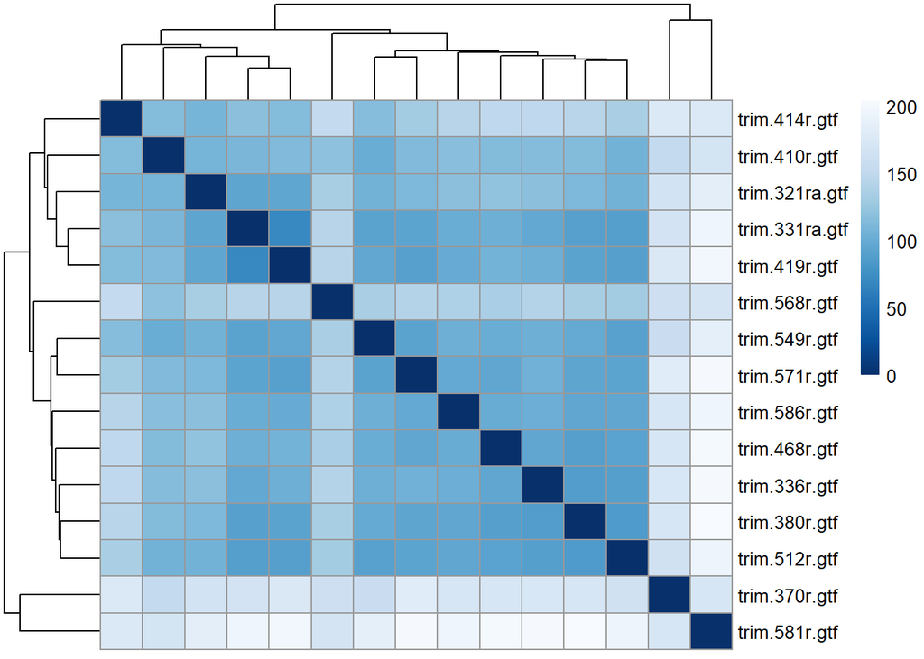

```r
gsampleDists_2 <- dist(t(assay(gvst_2))) #calculate distance matix
gsampleDistMatrix_2 <- as.matrix(gsampleDists_2) #distance matrix
rownames(gsampleDistMatrix_2) <- colnames(gvst_2) #assign row names
colnames(gsampleDistMatrix_2) <- NULL #assign col names
colors <- colorRampPalette( rev(brewer.pal(9, "Blues")) )(255) #assign colors
save_pheatmap_pdf <- function(x, filename, width=7, height=7) {
  stopifnot(!missing(x))
  stopifnot(!missing(filename))
  pdf(filename, width=width, height=height)
  grid::grid.newpage()
  grid::grid.draw(x$gtable)
  dev.off()
}

pht_2<-pheatmap(gsampleDistMatrix_2, #plot matrix
              clustering_distance_rows=gsampleDists_2, #cluster rows
              clustering_distance_cols=gsampleDists_2, #cluster columns
              col=colors) #set colors
```

```r
save_pheatmap_pdf(pht, "figures/acropora/acr_sample_distances_2.pdf")
```

```r
dev.off()
```

Heatmap shows a clear diagnol line emphasising that the metadata is correctly mapping to the right sample in the genecount matrix.

#Looking at the dispersion/variance of samples using perm_disp

```r
condition <- colData(gdds_2)$eatenvscontrol

# Run the PERMDISP test using the distance matrix and condition
permdisp_result <- betadisper(gsampleDists_2, condition)

# View the summary of PERMDISP result
summary(permdisp_result)
```

```
##                 Length Class  Mode
## eig              14    -none- numeric
## vectors         210    -none- numeric
## distances        15    -none- numeric
## group            15    factor numeric
## centroids        28    -none- numeric
## group.distances   2    -none- numeric
## call              3    -none- call
```

```r
# Step 2: Perform an ANOVA on the betadisper result
permdisp_anova <- anova(permdisp_result)

# Step 3: Extract the p-value from the ANOVA result
p_value <- permdisp_anova$`Pr(>F)`[1]

# Step 4: Print the p-value
print(p_value)
```

```
## [1] 0.00804436
```

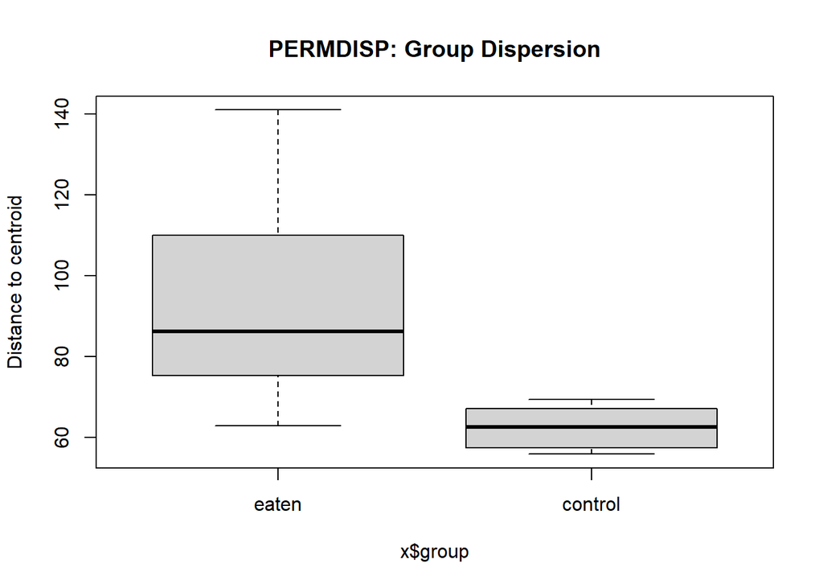

```r
# Plot PERMDISP result (dispersion by group)
boxplot(permdisp_result, main = "PERMDISP: Group Dispersion")
```

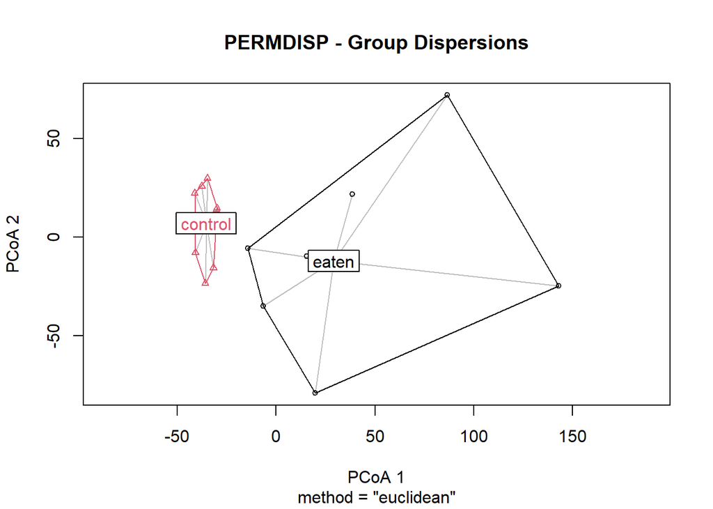

```r
# Optionally, use a scatter plot to see dispersion
plot(permdisp_result, main = "PERMDISP - Group Dispersions")
```

Lots of dispersion for the eaten samples - unsuprising. ANOVA p-value = 0.00804436 which shows there is a significant dispersion due to the treatments (eaten vs control)

# Conduct a PERMANOVA and PCA for all genes

```r
#Export data for PERMANOVA test.
test_2<-t(assay(gvst_2)) #export as matrix
test_2<-as.data.frame(test_2)
#add category columns
test_2$sample<-rownames(test_2)
test_2$eatenvscontrol<-metadata_2$eatenvscontrol[match(test_2$sample, metadata_2$sample)]
dim(test_2)
```

```
## [1]    15 18260
```

```r
ncol(test_2) - 2
```

```
## [1] 18258
```

Two of these 18260 columns are metadata so real value is 1.8258^{4} genes **as expected**

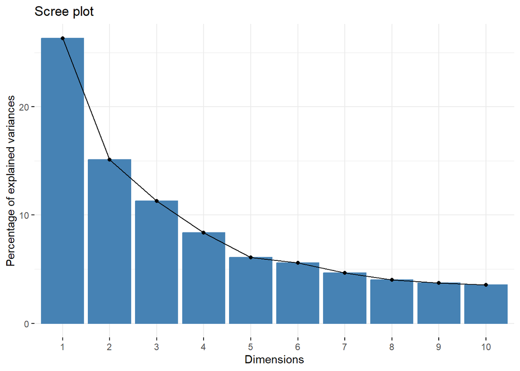

```r
scaled_test_2 <-prcomp(test_2[c(1:18258)], scale=TRUE, center=TRUE)
fviz_eig(scaled_test_2)
```

```r
# scale data
vegan_2 <- scale(test_2[c(1:18258)])

# PerMANOVA
permanova_2<-adonis2(vegan_2 ~ eatenvscontrol, data = test_2, method='eu')
permanova_2
```

```
## Permutation test for adonis under reduced model
## Permutation: free
## Number of permutations: 999
##
## adonis2(formula = vegan_2 ~ eatenvscontrol, data = test_2, method = "eu")
##          Df SumOfSqs      R2      F Pr(>F)
## Model     1    39100 0.15297 2.3477  0.002 **
## Residual 13   216512 0.84703
## Total    14   255612 1.00000
## ---
## Signif. codes:  0 '***' 0.001 '**' 0.01 '*' 0.05 '.' 0.1 ' ' 1
```

# Plot a PCA of samples by eatenvscontrol phenotype for all genes.

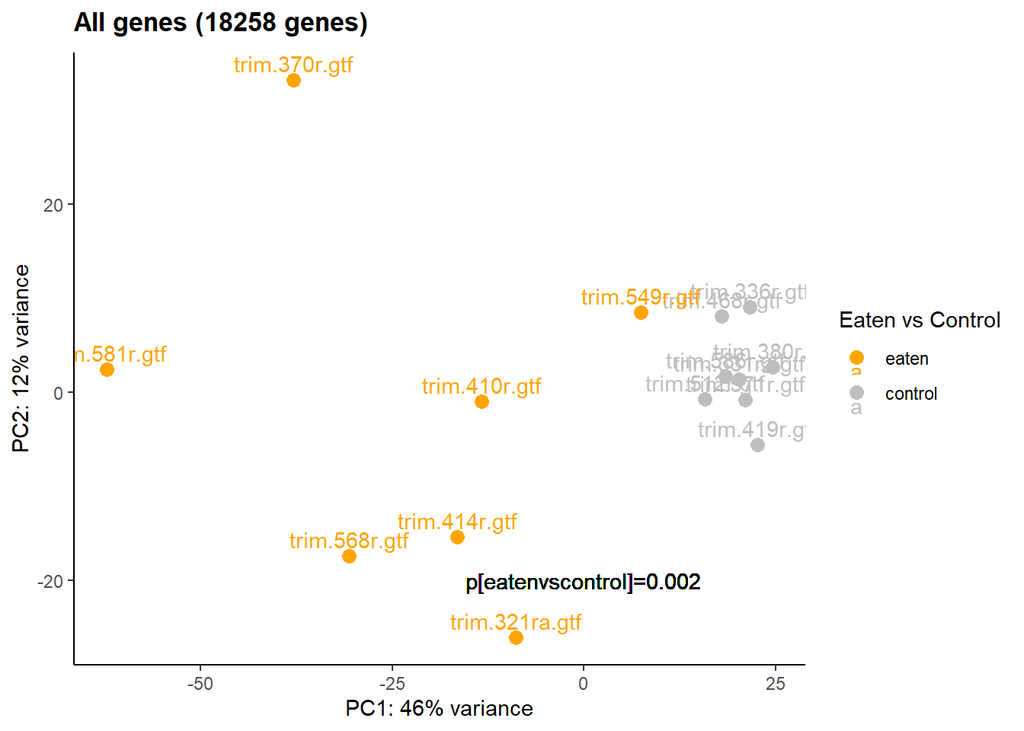

```r
gPCAdata_2 <- plotPCA(gvst_2, intgroup = c("eatenvscontrol"), returnData=TRUE)
percentVar_2 <- round(100*attr(gPCAdata_2, "percentVar"))

allgenesfilt_PCA_2 <- ggplot(gPCAdata_2, aes(PC1, PC2, color=eatenvscontrol)) +   geom_point(size=3) +
  ggtitle(expression(bold("All genes (18258 genes)")))+
  geom_text(aes(x = PC1, y = PC2, label = name), vjust = -0.5) +
  xlab(paste0("PC1: ",percentVar_2[1],"% variance")) +
  ylab(paste0("PC2: ",percentVar_2[2],"% variance")) +
  scale_color_manual(name="Eaten vs Control", values=c("control"="gray", "eaten"="orange"))+
  geom_text(x=0, y=-20, label="p[eatenvscontrol]=0.002", color="black")+
  theme_classic() + #Set background color
  theme(panel.border = element_blank(), # Set border
        #panel.grid.major = element_blank(), #Set major gridlines
        #panel.grid.minor = element_blank(), #Set minor gridlines
        axis.line = element_line(colour = "black"), #Set axes color
        plot.background=element_blank()); allgenesfilt_PCA_2
```

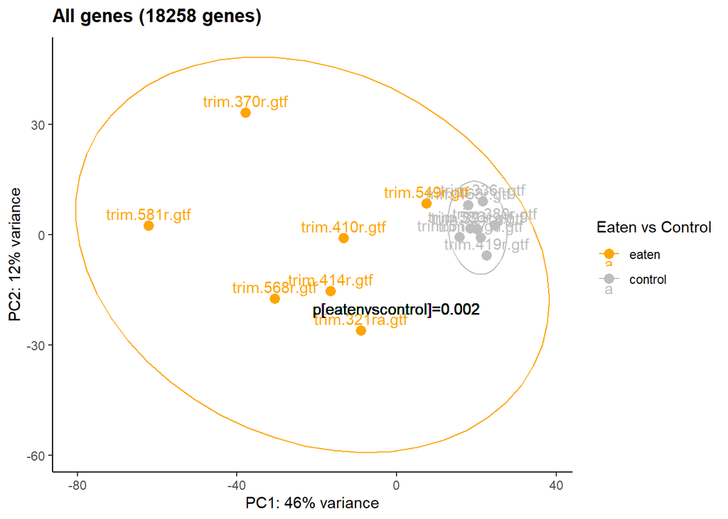

```r
ggsave("figures/acropora/pca_acr_2.pdf", allgenesfilt_PCA_2, width=8, height=4)
ggsave("figures/acropora/pca_acr_2.jpeg", allgenesfilt_PCA_2, width=8, height=4)

#Add a plot with elipses.
allgenes_ellipse_2<-allgenesfilt_PCA_2 + stat_ellipse();allgenes_ellipse_2
```

```r
ggsave("figures/acropora/pca_acr_ellipse_2.pdf", allgenes_ellipse_2, width=9, height=5)
ggsave("figures/acropora/pca_acr_ellipse_2.jpeg", allgenes_ellipse_2, width=9, height=5)
```

We can see from the PCA that removing sample 497R has reduced PC2 variance from 14 to 12%. PC1 variance has increased from 41 to 46%.

# Run DEG analysis of eatenvscontrol

Examine DEGs - using the Wald test for comparisons between the two groups.

1. View DEG’s by eatenvscontrol

```r
#Run Wald test.
DEG_T <- DESeq(gdds_2, test="Wald")

#View results by eatenvscontrol effects. Create dataframe for each comparison and add a column for the specific contrast.
resultsNames(DEG_T)
```

```
## [1] "Intercept"                       "eatenvscontrol_control_vs_eaten"
```

```r
#this shows the comparisons made (shown similar to lm output in terms of interactions)
head(DEG_T)
```

```
## class: DESeqDataSet
## dim: 6 15
## metadata(1): version
## assays(6): counts mu ... replaceCounts replaceCooks
## rownames(6): Ahyacinthus26343 Ahyacinthus26344 ... Ahyacinthus07915
##   Ahyacinthus07916
## rowData names(23): baseMean baseVar ... maxCooks replace
## colnames(15): trim.321ra.gtf trim.331ra.gtf ... trim.581r.gtf
##   trim.586r.gtf
## colData names(5): sample eatenvscontrol code sizeFactor replaceable
```

```r
eatenvscontrol<-results(DEG_T, contrast=c("eatenvscontrol","control","eaten"))
gene_names <- rownames(DEG_T)
sample_names <- colData(DEG_T)
eatenvscontrol <- as.data.frame(eatenvscontrol)
eatenvscontrol <- eatenvscontrol %>%
  mutate(gene_ID = rownames(eatenvscontrol))
eatenvscontrol <- subset(eatenvscontrol, padj<0.05)
eatenvscontrol$contrast <- c("eatenvscontrol")
dim(eatenvscontrol)
```

```
## [1] 1405    8
```

```r
write.csv(eatenvscontrol,"data/DEG_acr.csv", row.names = FALSE)
```

```r
#Create gene_counts_long
gene_counts <- counts(DEG_T, normalized = TRUE)
gene_counts_df <- as.data.frame(gene_counts)
gene_counts_df$gene_id <- rownames(gene_counts_df)
library(tidyr)
gene_counts_long <- pivot_longer(
  gene_counts_df,
  cols = -gene_id,
  names_to = "sample",
  values_to = "count"
)
```

```r
# Create counts_annotated
eatenvscontrol <- results(DEG_T, contrast = c("eatenvscontrol", "control", "eaten"))
# Turn into dataframe and add gene IDs
de_df <- as.data.frame(eatenvscontrol)
de_df$gene_id <- rownames(de_df)
# View or filter DE genes
head(de_df)
```

```
##                   baseMean log2FoldChange     lfcSE       stat     pvalue
## Ahyacinthus26343  58.71493     -0.9191198 2.0240782 -0.4540930 0.64976187
## Ahyacinthus26344  44.18055     -0.6658323 1.4641798 -0.4547477 0.64929079
## Ahyacinthus07918 345.93352      0.6888089 0.6190498  1.1126873 0.26584277
## Ahyacinthus07914 315.41387      0.6861579 0.6298747  1.0893563 0.27599680
## Ahyacinthus07915 641.24443      0.5793760 0.2703784  2.1428339 0.03212644
## Ahyacinthus07916 148.92386      0.8652015 0.9473632  0.9132733 0.36109881
##                       padj          gene_id
## Ahyacinthus26343        NA Ahyacinthus26343
## Ahyacinthus26344        NA Ahyacinthus26344
## Ahyacinthus07918 0.5349112 Ahyacinthus07918
## Ahyacinthus07914 0.5456011 Ahyacinthus07914
## Ahyacinthus07915 0.1635179 Ahyacinthus07915
## Ahyacinthus07916 0.6283065 Ahyacinthus07916
```

```r
sig_genes <- de_df[which(de_df$padj < 0.05), ]
#Create dataframe of DEGs with sample info too
norm_counts <- counts(DEG_T, normalized = TRUE)
norm_counts_df <- as.data.frame(norm_counts)
norm_counts_df$gene_id <- rownames(norm_counts_df)
library(tidyr)
counts_long <- pivot_longer(norm_counts_df,
                             cols = -gene_id,
                             names_to = "sample",
                             values_to = "count")
sample_meta <- as.data.frame(colData(DEG_T))
sample_meta$sample <- rownames(sample_meta)
library(dplyr)
counts_annotated <- left_join(counts_long, sample_meta, by = "sample")
```

```r
#Combine this list of DEGs into one dataframe.
DEG_eatenvscontrol<-rbind(eatenvscontrol)
DEG_eatenvscontrol
```

```
## log2 fold change (MLE): eatenvscontrol control vs eaten
## Wald test p-value: eatenvscontrol control vs eaten
## DataFrame with 18258 rows and 6 columns
##                   baseMean log2FoldChange     lfcSE      stat    pvalue
##                  <numeric>      <numeric> <numeric> <numeric> <numeric>
## Ahyacinthus26343   58.7149      -0.919120  2.024078 -0.454093 0.6497619
## Ahyacinthus26344   44.1805      -0.665832  1.464180 -0.454748 0.6492908
## Ahyacinthus07918  345.9335       0.688809  0.619050  1.112687 0.2658428
## Ahyacinthus07914  315.4139       0.686158  0.629875  1.089356 0.2759968
## Ahyacinthus07915  641.2444       0.579376  0.270378  2.142834 0.0321264
## ...                    ...            ...       ...       ...       ...
## Ahyacinthus15071   634.715      0.5777352  0.639648  0.903207  0.366416
## Ahyacinthus15072   123.860     -0.8268333  0.708555 -1.166929  0.243239
## Ahyacinthus15073   388.299      0.6515780  0.613116  1.062733  0.287903
## Ahyacinthus15078  5024.000      0.2961848  0.202337  1.463819  0.143243
## Ahyacinthus15079  1730.700      0.0883648  0.224385  0.393809  0.693722
##                       padj
##                  <numeric>
## Ahyacinthus26343        NA
## Ahyacinthus26344        NA
## Ahyacinthus07918  0.534911
## Ahyacinthus07914  0.545601
## Ahyacinthus07915  0.163518
## ...                    ...
## Ahyacinthus15071  0.632612
## Ahyacinthus15072  0.511729
## Ahyacinthus15073  0.557754
## Ahyacinthus15078  0.386282
## Ahyacinthus15079  0.854959
```

```r
head(DEG_eatenvscontrol)
```

```
## log2 fold change (MLE): eatenvscontrol control vs eaten
## Wald test p-value: eatenvscontrol control vs eaten
## DataFrame with 6 rows and 6 columns
##                   baseMean log2FoldChange     lfcSE      stat    pvalue
##                  <numeric>      <numeric> <numeric> <numeric> <numeric>
## Ahyacinthus26343   58.7149      -0.919120  2.024078 -0.454093 0.6497619
## Ahyacinthus26344   44.1805      -0.665832  1.464180 -0.454748 0.6492908
## Ahyacinthus07918  345.9335       0.688809  0.619050  1.112687 0.2658428
## Ahyacinthus07914  315.4139       0.686158  0.629875  1.089356 0.2759968
## Ahyacinthus07915  641.2444       0.579376  0.270378  2.142834 0.0321264
## Ahyacinthus07916  148.9239       0.865202  0.947363  0.913273 0.3610988
##                       padj
##                  <numeric>
## Ahyacinthus26343        NA
## Ahyacinthus26344        NA
## Ahyacinthus07918  0.534911
## Ahyacinthus07914  0.545601
## Ahyacinthus07915  0.163518
## Ahyacinthus07916  0.628306
```

```r
dim(DEG_eatenvscontrol)
```

```
## [1] 18258     6
```

```r
length(unique(DEG_eatenvscontrol$gene_ID))
```

```
## [1] 0
```

```r
#Get a VST normalized gene count matrix for these DEGs.This isn't knitting correctly so blocked out.
#DEG_eatenvscontrol_vst <- gdds_2[unique(DEG_eatenvscontrol$gene)]
#dim(DEG_eatenvscontrol_vst)
# Now apply variance stabilizing transformation
#DEG_eatenvscontrol_vst <- varianceStabilizingTransformation(DEG_eatenvscontrol_vst)
```

# Plot a heatmap for eatenvscontrol DEGs.

```r
#Previous chunk not working so had to block out this one too since it uses object computed in previous chunk
#Set themes and metadata.
#colnames(colData(gdds_2))
#legend_names_col <- colnames(assay(DEG_eatenvscontrol_vst))
#df <- as.data.frame(colData(gdds_2))
#colnames(df) <- tolower(trimws(colnames(df)))
#df$eatenvscontrol <- factor(as.character(df$eatenvscontrol), #levels=c("eaten", "control"))
#df$eatenvscontrol <- relevel(df$eatenvscontrol, ref = "control")

#df<-df%>%
 # arrange(eatenvscontrol)%>%dplyr::select(!code)%>%dplyr::select(!sample)

#ann_colors = list(eatenvscontrol = c("control" = "gray", "eaten"= "orange"))

#DEG_acr_eatenvscontrol <- pheatmap(assay(DEG_eatenvscontrol_vst), cluster_rows=TRUE, show_rownames=FALSE, color=inferno(10), show_colnames=TRUE, fontsize_row=3, scale="row", cluster_cols=TRUE, annotation_col=df, annotation_colors = ann_colors, labels_col=legend_names_col)

#save_pheatmap_pdf(DEG_acr_eatenvscontrol, "figures/acropora/DEG_acr_eatenvscontrol.pdf", width=15, height=20)
#dev.off()
```

# Plot PCA of DEGs

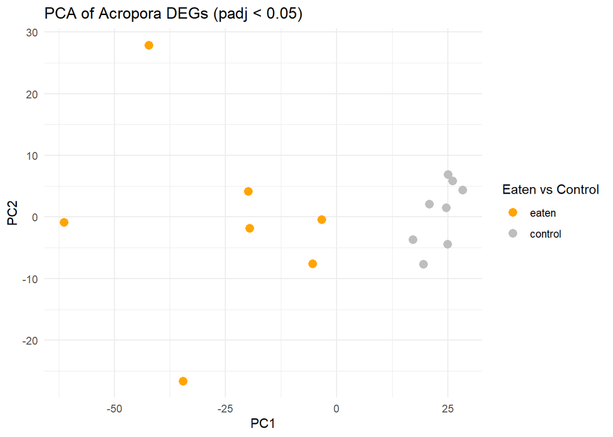

```r
#Subset genes with padj < 0.05
sig_genes <- eatenvscontrol[which(eatenvscontrol$padj < 0.05), ]
# Get the gene IDs of the significant genes
sig_gene_ids <- rownames(sig_genes)
# Subset the normalized counts to keep only significant genes
sig_counts <- norm_counts[sig_gene_ids, ]
# rlog transformation (can also use vst for variance-stabilizing)
rld <- vst(DEG_T)

# Get the transformed counts
rld_mat <- assay(rld)

# Subset the transformed counts to include only significant genes
rld_sig_genes <- rld_mat[sig_gene_ids, ]
# Run PCA (t() is important to transpose for PCA, where rows are samples)
pca <- prcomp(t(rld_sig_genes), scale. = TRUE)

# Create a dataframe with PCA results
pca_df <- as.data.frame(pca$x)
pca_df$sample <- rownames(pca_df)
sample_meta <- as.data.frame(colData(DEG_T))
sample_meta$sample <- rownames(sample_meta)

# Merge PCA results with sample metadata
pca_df <- left_join(pca_df, sample_meta, by = "sample")
acr_pca_deg <- ggplot(pca_df, aes(x = PC1, y = PC2, colour = eatenvscontrol)) +
  geom_point(size = 3) +
  labs(title = "PCA of Acropora DEGs (padj < 0.05)", x = "PC1", y = "PC2") +
  scale_color_manual(name="Eaten vs Control", values=c("control"="gray", "eaten"="orange")) +
  theme_minimal()
plot(acr_pca_deg)
```

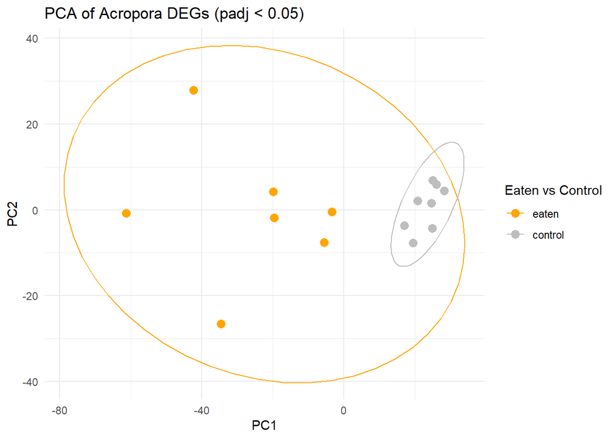

```r
ggsave("figures/acropora/acr_pca_deg.pdf", acr_pca_deg, width=8, height=4)
ggsave("figures/acropora/acr_pca_deg.jpeg", acr_pca_deg, width=8, height=4)

#Add a plot with elipses.
acr_pca_deg_ellipse<-acr_pca_deg + stat_ellipse();acr_pca_deg_ellipse
```

```r
ggsave("figures/acropora/acr_pca_deg_ellipse.pdf", acr_pca_deg_ellipse, width=9, height=5)
ggsave("figures/acropora/acr_pca_deg_ellipse.jpeg", acr_pca_deg_ellipse, width=9, height=5)
```